# 8_1_ARIMA_Differencing

# References

1. Forecasting Principles and Practice. Hyndman & Athanasopoulos. [Link](https://otexts.com/fpp3/)
2. Time Series - A Data Analysis approach using R. Shumway & Stoffer.
3. Time Series Analysis and its Applications - Shumway & Stoffer.

# Stationarity

In general, in the fieldsof physics, stationary refers to a process whose properties do not change over time.

A **stationary time series** is one **whose statistical properties do not depend on the time at which the series is observed**.

## A formal definition

Recall that time series can be understood as a **collection of random variables indexed over time.**

- **The observations available** would be realisations of the random variable.
- **Future values of the time series** may be thought of as a collection of random variables that are yet to be realised.

If ${y_t}$ is stationary, then, **for all** $s$, the distribution of $(y_t,\dots,y_{t+s})$ does not depend on $t$.

That is, formally stationarity has to do with the joint distribution of the process as it evolves in time. Strictly speaking a time series is stationary if its probabilistic behavior does not change with time, hence in this sense we say that a series is **strictly stationary** if the joint probability distribution of the random variables of the time series does not change from time $t$ to time $t+h$

$$P(x_{t_1}\leq c_1,\dots x_{t_n}\leq c_n)=P(x_{t_1+h}\leq c_1,\dots, x_{t_n+h}\leq c_n)$$
This condition, however, is too strict for for most applications. We may achieve a **somewhat milder definition** of **weak stationarity**:

1. the **mean value is constant and does not depend on time**
2. the **autocovariance function** depends **only on the difference between the time moments**, $|s-t|$, and **not on the location of the two points.**

From now on, whenever we say *stationary* we actually mean it in the *weak stationarity sense*, meaning that the two conditions above are satisfied.

## Practical identification of stationarity

The above formal definition translates in specific characteristics of a stationary time series:

- It is roughly horizontal, with **no trend.**
- Its **variance remains constant** over time
- Presents **no predictable patterns in the long-term**
  - **Seasonal time series are NOT stationary**.

## Visually recognising non-stationary data

- **Time plot:** will show the series to be roughly horizontal, although some cyclic behavior is possible, with constant variance.
- **ACF plot**
  - Stationary time series have an ACF that drops to 0 relatively quickly
  - Non-stationary time series: the ACF decreases slowly.
- **r1 value (first autocorrelation)**
  - For non-stationary time series r1 is often large and positive (first values of the series are close). This is however not a formal test.

## Examples

Let us start with an example given in reference [2]. The image below shows an example of a stationary vs a non-stationary process. The series on the left has no trend and the time series behaves the same between the first 50 points and the rest of the points. The right one has a trend and it also behaves differently between observations 1-50 and 150 to 200. Observations 1-50 have a different mean and variance than observations 150-200 (the end being more variable).

[figure not shown]

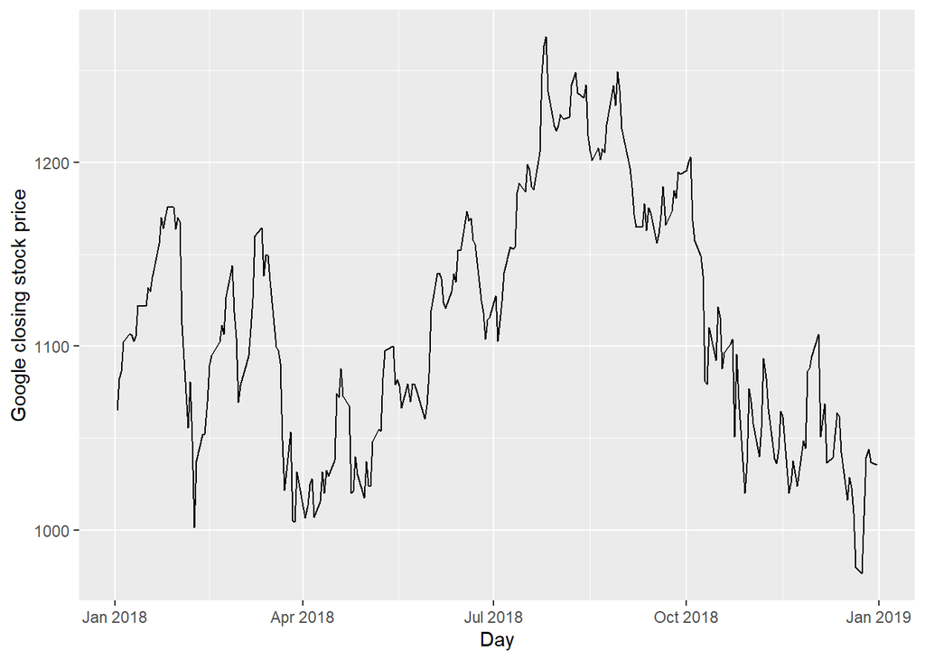

```r
gafa_stock %>%
  filter(Symbol == "GOOG", year(Date) == 2018) %>%
  autoplot(Close) +
  labs(y = "Google closing stock price", x = "Day")
```

```
Response variable not specified, automatically selected `var = Open`
```

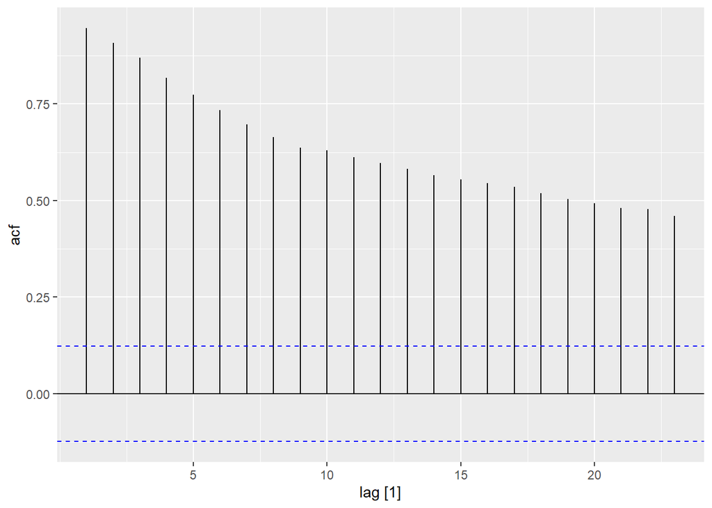

```r
gafa_stock %>%
  filter(Symbol == "GOOG", year(Date) == 2018) %>%
  ACF() %>%
  autoplot()
```

We can remove the trend from this time-series simply by differencing (we will study this later in the session)

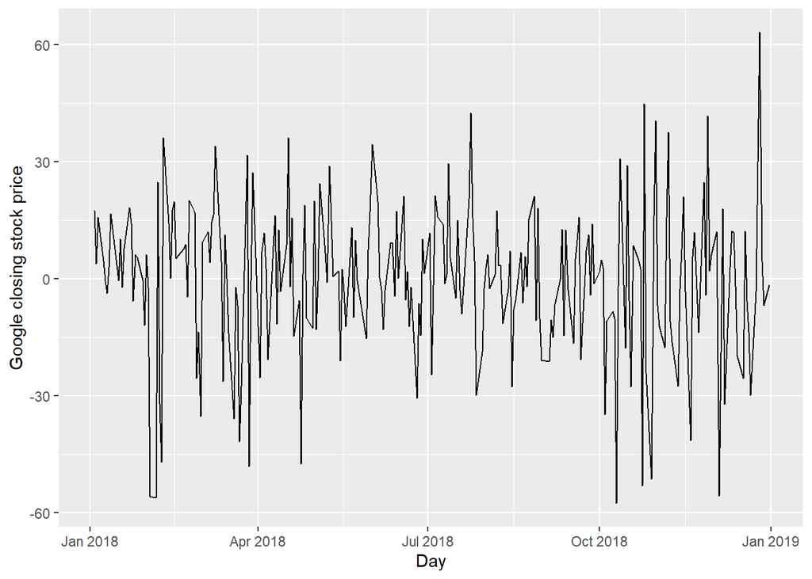

```r
gafa_stock %>%
  filter(Symbol == "GOOG", year(Date) == 2018) %>%
  autoplot(difference(Close)) +
  labs(y = "Google closing stock price", x = "Day")
```

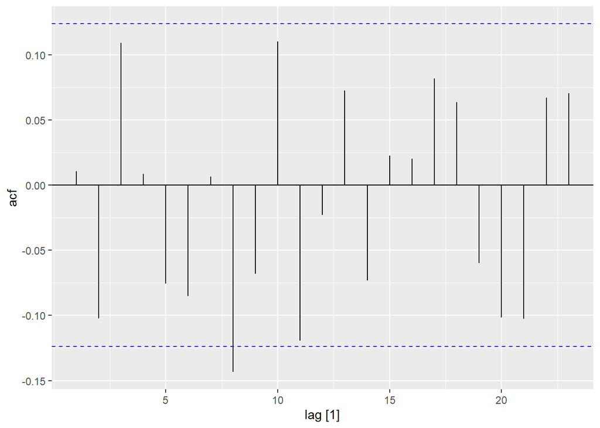

```r
gafa_stock %>%
  filter(Symbol == "GOOG", year(Date) == 2018) %>%
  ACF(difference(Close)) %>%
  autoplot()
```

We see the series has turned white noise, the correlogram does no longer exhibit a trend.

Another example:

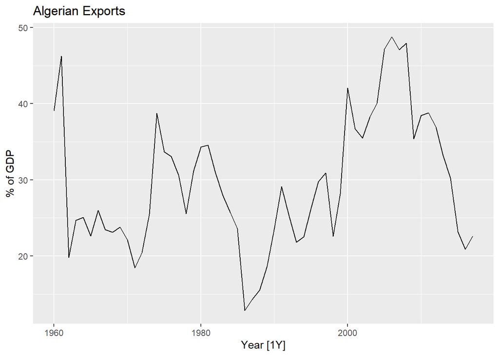

```r
algeria <- global_economy %>%
            filter(Country == "Algeria")

algeria %>%
  autoplot(Exports) +
  labs(y = "% of GDP", title = "Algerian Exports")
```

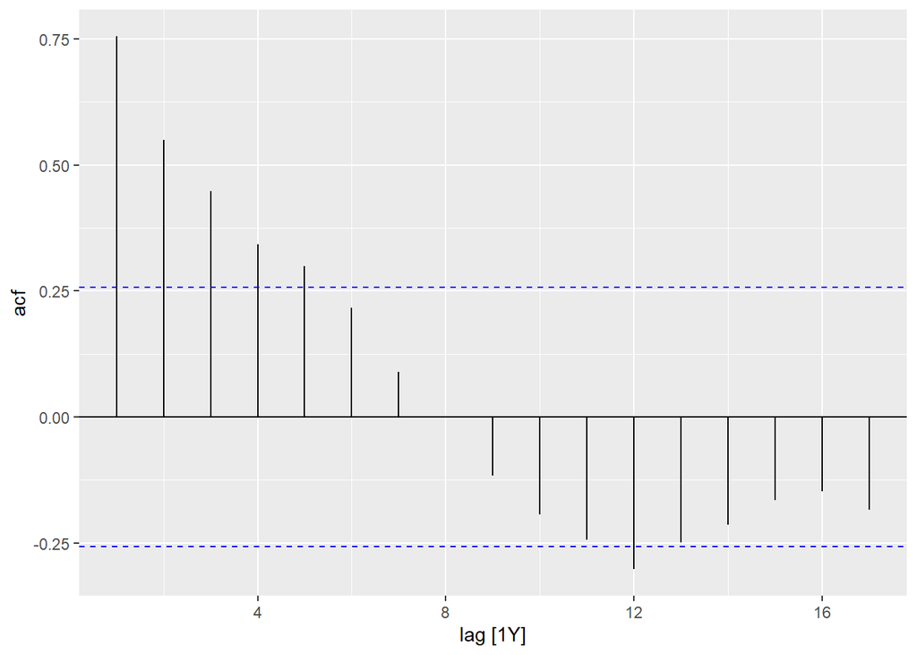

```r
algeria %>% ACF(Exports) %>% autoplot()
```

The series exhibits a slowly decatying ACF resulting from the trend-cycle component. We can see that this goes away with first order differencing:

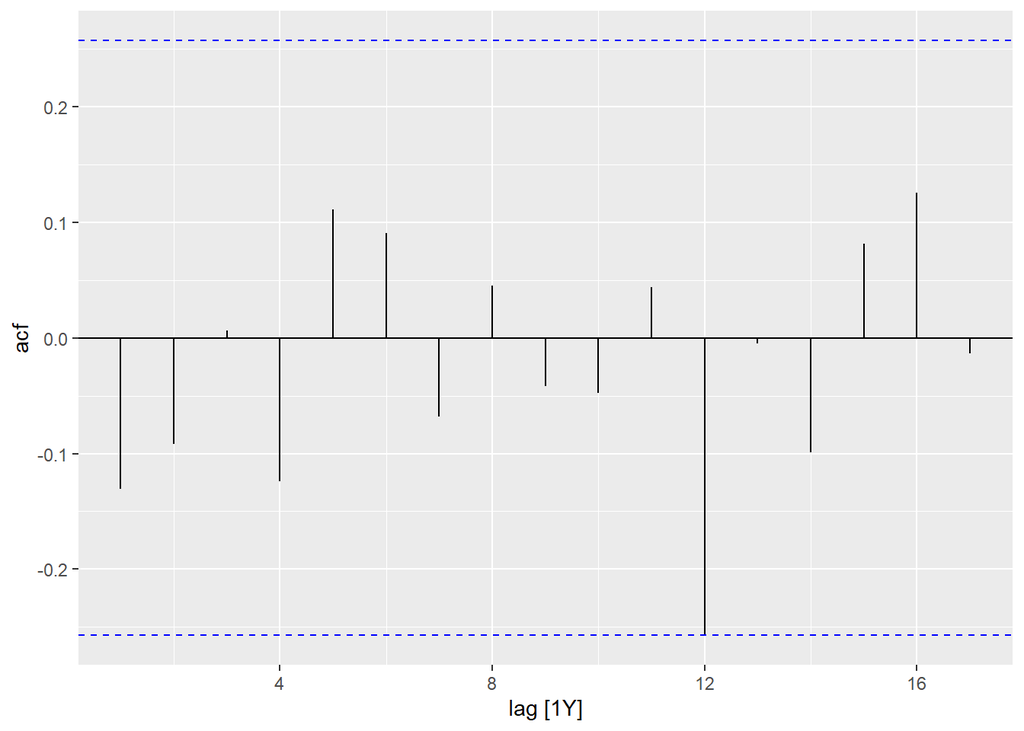

```r
algeria %>%
  mutate(exports_1d = Exports %>% difference(1)) %>% ACF(exports_1d) %>% autoplot()
```

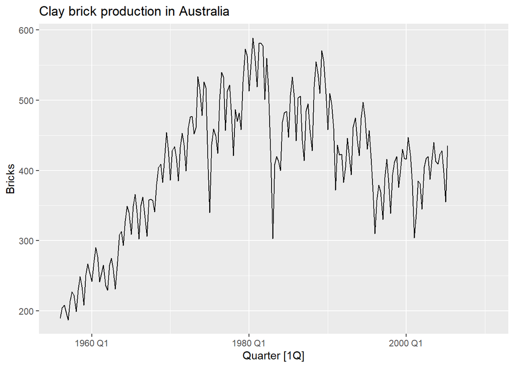

```r
aus_production %>%
  autoplot(Bricks) +
  labs(title = "Clay brick production in Australia")
```

This series presents trend, seasonality and also changes in its variance over time

Let us now examine how the time period considered can play a role:

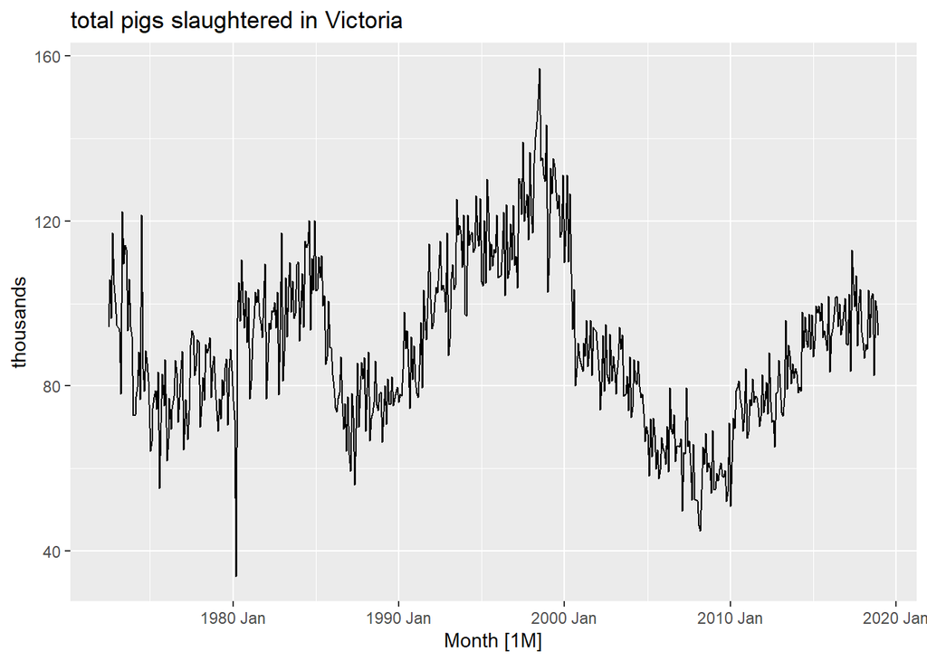

```r
aus_livestock %>%
  filter(Animal == "Pigs", State == "Victoria") %>%
  autoplot(Count/1e3) +
  labs( y = "thousands", title = "total pigs slaughtered in Victoria")
```

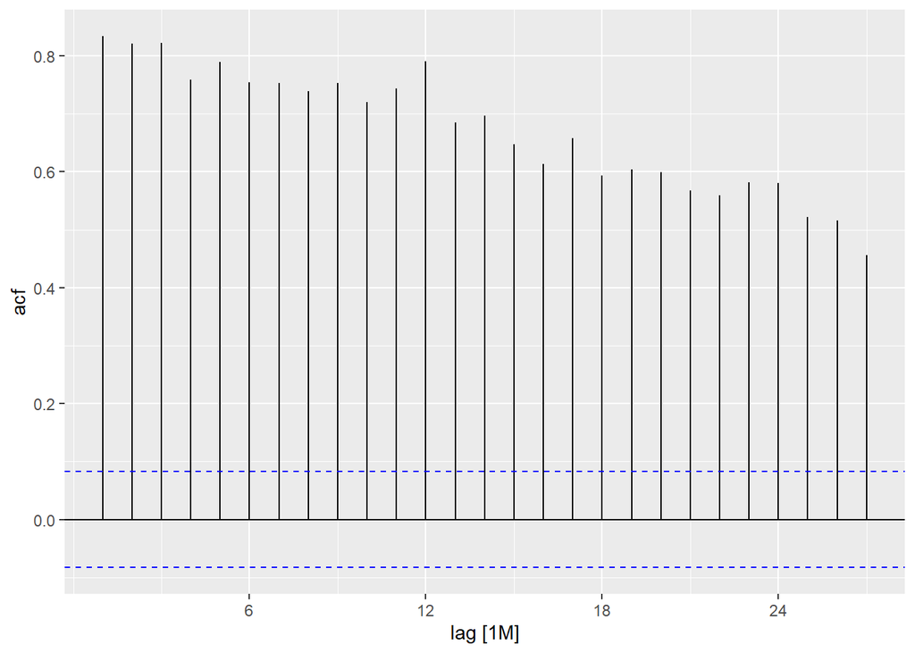

```r
aus_livestock %>%
  filter(Animal == "Pigs", State == "Victoria") %>%
  ACF(Count/1e3) %>% autoplot()
```

Clearly this series exhibits a very strong trend as well as seasonality. Not stationary.

Now lets consider 2010 onwards:

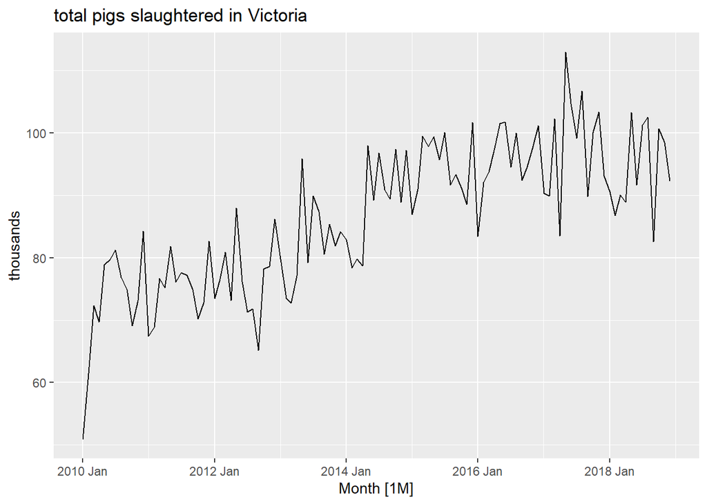

```r
aus_livestock %>%
  filter(Animal == "Pigs", State == "Victoria", year(Month) >= 2010) %>%
  autoplot(Count/1e3) +
  labs( y = "thousands", title = "total pigs slaughtered in Victoria")
```

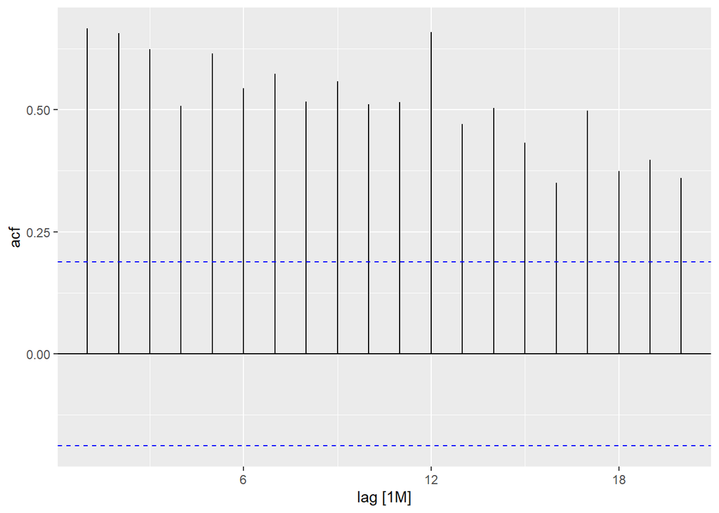

```r
aus_livestock %>%
  filter(Animal == "Pigs", State == "Victoria", year(Month) >= 2010) %>%
  ACF(Count/1e3) %>% autoplot()
```

The strength of the ACF coefficients is smaller, but the series also has very clearly seasonality and trend.

Now if we consider observations from 2015 onwards:

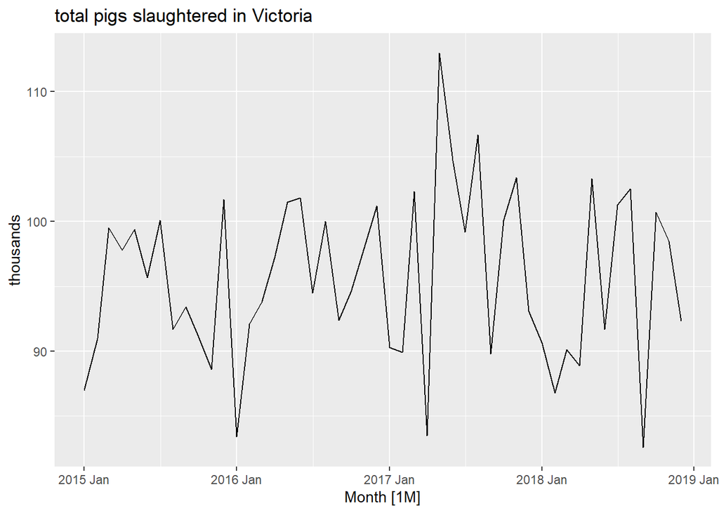

```r
aus_livestock %>%
  filter(Animal == "Pigs", State == "Victoria", year(Month) >= 2015) %>%
  autoplot(Count/1e3) +
  labs( y = "thousands", title = "total pigs slaughtered in Victoria")
```

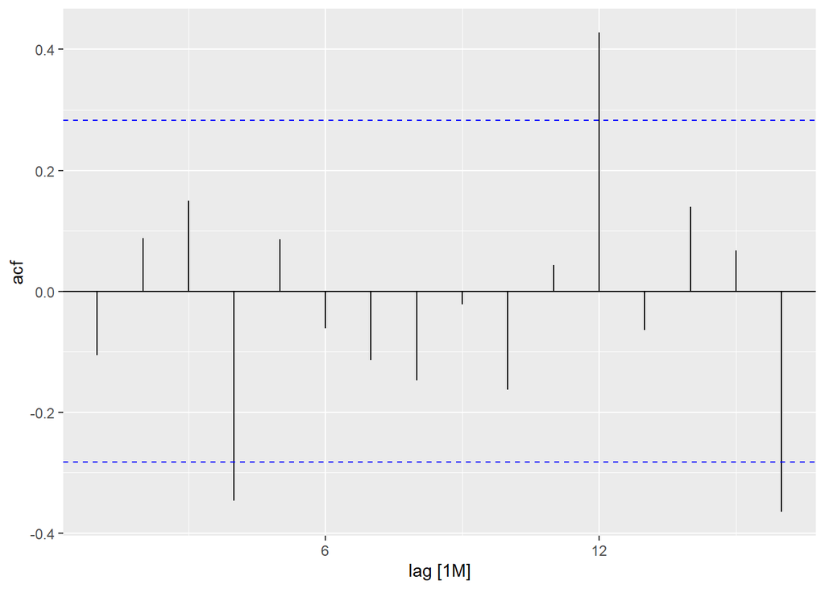

```r
aus_livestock %>%
  filter(Animal == "Pigs", State == "Victoria", year(Month) >= 2015) %>%
  ACF(Count/1e3) %>% autoplot()
```

Now this series looks much more like white noise. Beware that an non-stationary time series can look stationary if only a certain subset of the data is considered.

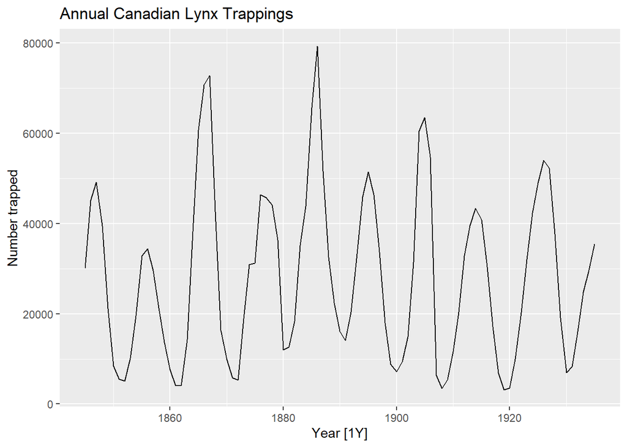

```r
pelt %>%
  autoplot(Lynx) +
  labs(y = "Number trapped", title = "Annual Canadian Lynx Trappings")
```

**A time series with cyclic behavior (but no trend or seasonality) is stationary.** This is because **cycles are not of fixed length**, before we observe the series we cannot be sure where the peaks and throughs of the cycles will be.

Although the strong cycles might appear to make it non-stationary, these are aperiodic (caused when the lynx population becomes too large for the available feed). In the long term, **the timing of these cycles is not predictable**.

Some more examples (some are repatead):

[figure not shown]

(a) Google closing stock price in 2015;

(b) Daily change in the Google stock price in 2015; (c) Annual number of strikes in the US;

(d) Monthly sales of new one-family houses sold in the US;

(e) Annual price of a dozen eggs in the US (constant dollars);

(f) Monthly total of pigs slaughtered in Victoria, Australia;

(g) Annual total of Canadian Lynx furs traded by the Hudson Bay Company;

(h) Quarterly Australian beer production; (i) Monthly Australian gas production.

From [1]:

*Obvious seasonality rules out series (d), (h) and (i).*

*Trends and changing levels rules out series (a), (c), (e), (f) and (i). Increasing variance also rules out (i).*

*That leaves only (b) and (g) as stationary series. Even in the case of (b) we would have to be careful since there could be increasing or changing variance, which is itself a form of non-stationarity.*

*At first glance, the strong cycles in series (g) might appear to make it non-stationary. But these cycles are aperiodic — they are caused when the lynx population becomes too large for the available feed, so that they stop breeding and the population falls to low numbers, then the regeneration of their food sources allows the population to grow again, and so on. In the long-term, the timing of these cycles is not predictable. Hence the series is stationary.*

# The importance of stationarity

## In generalin time series

Stationarity is important to us because it implies that we can use simple averaging to estimate correlations:

- Given $(x_1, ..., x_n)$, if the mean is constant we can estimate it simply by averaging.
- Pairs of points can be used to estimate the correlation of the different lags:
  - $(x1, x2)$ - $(x2, x3)$ - $(x3, x4) \text{ ... }$ and so on for lag 1
  - $(x1, x3)$ - $(x2, x4)$ - $(x3, x5) \text{ ... }$ and so on for lag 1
  - …

## In ARIMA

We will see that ARIMA stands for Autoregressive Integrated Moving Average models. We will be able to separate an ARIMA model into these three components.

Together, the Autoregressive (AR) and Moving Average (MA) models will constitute an ARMA model. The **time series modelled by an ARMA process needs to be stationary**, **ARMA models reproduce the dynamics of stationary time series**.

The mathematical underpinning of this fact is complex and can be found in reference 2. In short:

- The Wold decomposition shows that any stationary time series may be represented as a linear combination of white noise (ref 2).
- On the other hand it can be proven that any ARMA model can be expressed in a form that is a linear combination of white noise (ref 2).

Thus ARMA models are very well suited for stationary time series. We will not go into the formal demonstration of this (reference 2), but it is important that you keep this fact in mind.

# Differencing

The google stock prices example showed that, while the stock price was not stationary, the daily changes in the praice were stationary (although we should perhaps have a better look at the variance).

**Differencing** (computing the difference between consecutive observations) is one way to make a non-stationary time series stationary.

Specifically, differencing **removes changes in the level of a time series and therefore can reduce (or eliminate) trend and seasonality (we discuss later seasonal differences).**

- First-differencing or lag1-differencing (differencing between consecutive lags) can be helpful in removing trend non-stationarity.
- Seasonal-differencing (differences between observations in consecutive seasons) can be helpful in removing seasonal non-stationarity.

## First order differences (first order lag-1 differencing)

### Lag-1 differencing and the random walk model

The differenced series can be written as:

$$\begin{align*}
y'_t = y_t - y_{t-1}.
\end{align*}$$

- The differenced series has $T-1$ values, since it is not possible to compute a difference for the first observation.

If the differenced series is **white noise**, the model for the original series can be written as ($\varepsilon_t$ denotes white noise):

$$\begin{align*}
y_t - y_{t-1} = \varepsilon_t,
\end{align*}$$

Rearranging we arrive at the **random walk model**:

$$\begin{align*}
y_t = y_{t-1} + \varepsilon_t
\end{align*}$$

Widely **used for non-stationary data**, particularly **financial** and **economic** data. They typically have:

- long periods of apparent trends up or down
- sudden and unpredictable changes in direction

Please, bear this in mind: **a random walk is NOT a stationary process**.

### Random walk and the Naïve Model

The **random walk model** is the **reason for the naïve forecast method**. Since future movements are unpredictable (equally likely up or down), future forecasts of a random walk model are equal to the last observation.

### Random walk with drift

Model that **allows the differences to have a non-zero mean.** Then:

$$\begin{align*}
y_t - y_{t-1} = c + \varepsilon_t\quad\text{or}\quad {y_t = c + y_{t-1} + \varepsilon_t}
\end{align*}$$

- $c$ is the average of the changes between consecutive observations.
  - If $c>0 \rightarrow$ drift upwards (and vice-versa).

This is the **model behind the drift method, also studied in section 5.2.**

## Second order differencing (second order lag-1 differences)

Sometimes second order differencing can help achieve a stationary time-series:

$$\begin{align*}
y''_{t} &= y'_{t} - y'_{t - 1} \\
&= (y_t - y_{t-1}) - (y_{t-1}-y_{t-2})\\
&= y_t - 2y_{t-1} +y_{t-2}.
\end{align*}$$

It is almost never necessary to go beyond second-order differences.

If second order differencing does not help remove the trend, then **detrending** the time series using the estimate of the trend generated by a decomposition model is an alternative.

### Note

We will see later that ARIMA models deal with trend by differencing. If differencing does not help remove the trend and detrending is required, ARIMA models would not be able to deal with the trend automatically.

Separate models could be built for the de-trended (stationary) process and the trend:

- Detrended stationary process could be modelled separately using some suitable method (Damped ETS for example).
- The remaining stationary process could be modelled using an ARMA process.

## Seasonal differences

Difference between an observation and the corresponding observation in the foregoing season.

$$\begin{align*}
y'_t = y_t - y_{t-m}
\end{align*}$$

- $y_{t-m}$ are called **lag-**$m$ differences, we subtract the observation at a point $t-m$ (whereas normal lags are at point $t-1$)

If seasonally differenced data appear to be white noise, a proper model for the original data would be:

$$\begin{align*}
y_t = y_{t-m}+\varepsilon_t
\end{align*}$$

Forecasts of this model are equal to the **last observation from the last season**, which is what the **seasonal naïve method** does.

## Example 1: transformning and differencing

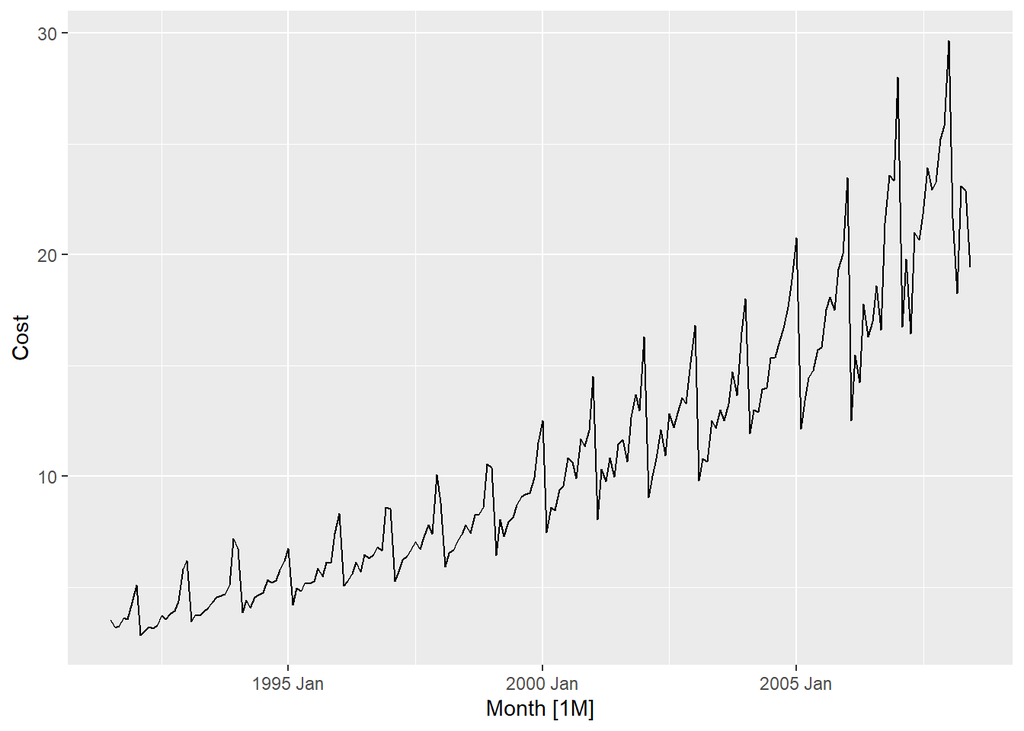

```r
a10 <- PBS %>%
  filter(ATC2 == "A10") %>%
  select(Month, Concession, Type, Cost) %>%
  summarise(Cost = sum(Cost)/1e6)

a10 %>% autoplot(
  Cost
)
```

Taking log transformations removes the increasing variance, which is itself a contributor to the non-stationarity.

**IMPORTANT POINT: transformations shall be applied prior to taking differences**

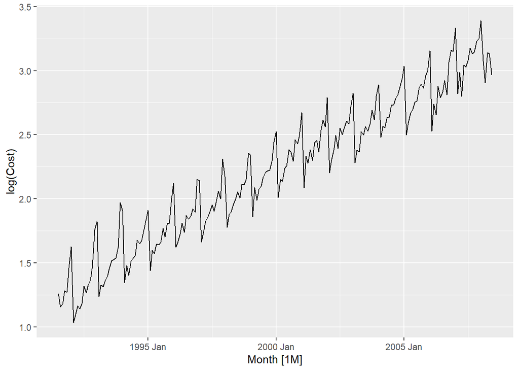

```r
a10 %>% autoplot(
  log(Cost)
)
```

### Option 1: lag-1 differences followed by seasonal differences

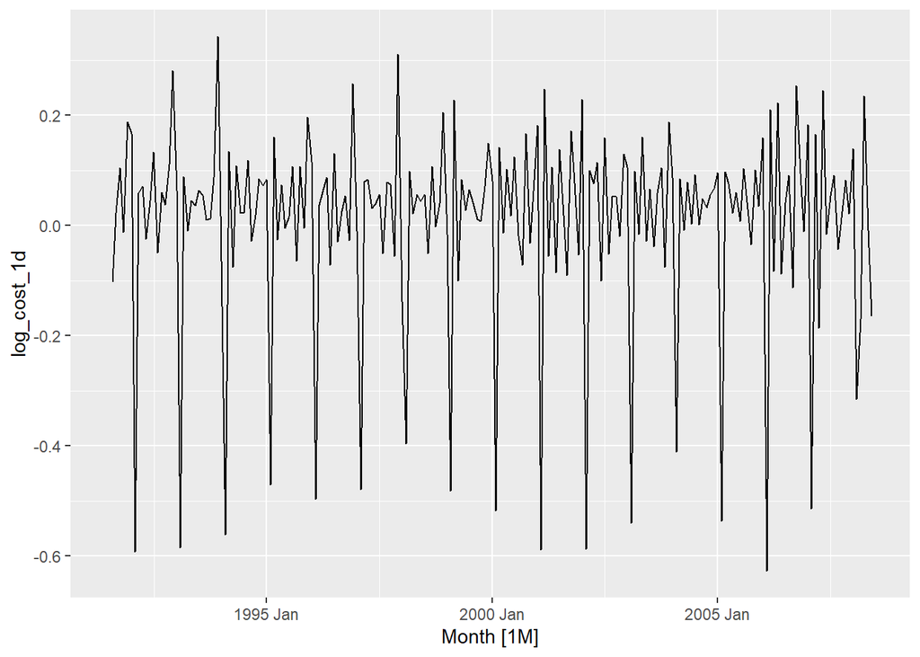

```r
a10 <- a10 %>% mutate(
  log_cost = log(Cost),
  log_cost_1d = log_cost %>% difference(1)
)

autoplot(a10, log_cost_1d)
```

```r
a10 <- a10 %>% mutate(
            log_cost_1d_12d = log_cost_1d %>% difference(12)
          )

a10
```

```
# A tsibble: 204 x 5 [1M]
      Month  Cost log_cost log_cost_1d log_cost_1d_12d
      <mth> <dbl>    <dbl>       <dbl>           <dbl>
 1 1991 Jul  3.53     1.26     NA                   NA
 2 1991 Aug  3.18     1.16     -0.103               NA
 3 1991 Sep  3.25     1.18      0.0222              NA
 4 1991 Oct  3.61     1.28      0.105               NA
 5 1991 Nov  3.57     1.27     -0.0126              NA
 6 1991 Dec  4.31     1.46      0.189               NA
 7 1992 Jan  5.09     1.63      0.167               NA
 8 1992 Feb  2.81     1.03     -0.592               NA
 9 1992 Mar  2.99     1.09      0.0591              NA
10 1992 Apr  3.20     1.16      0.0708              NA
# … with 194 more rows
```

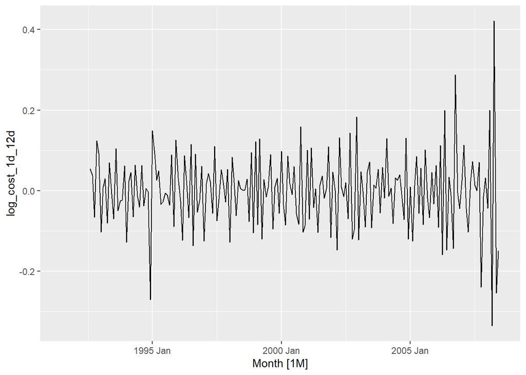

```r
autoplot(a10, log_cost_1d_12d)
```

We can see that now both the trend and the seasonality have been removed.

### Option 2: seasonal differences first

This option is worth trying because seasonal differences also have an effect of the trend. Therefore sometimes seasonal differencing is enough to remove both the trend and the seasonal component.

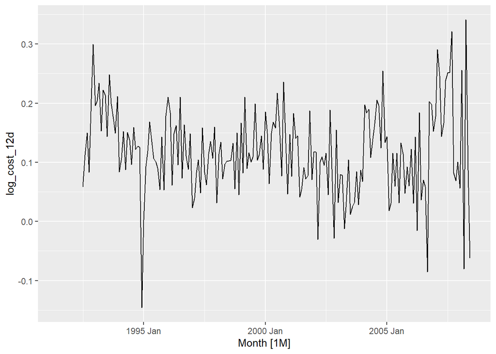

```r
a10 <- a10 %>% mutate(
  log_cost_12d = log_cost %>% difference(12)
)

autoplot(a10, log_cost_12d)
```

After seasonal differencing the series is relatively stationary (formal tests seen later). As observed, seasonal differencing also has an effect at removing the trend **so it can be interesting to apply seasonal differencing prior to lag-1 differencing to see if this is already sufficient to render the time series stationary**

Let us perform a unit root test to check if the time series is stationary. The specifics of this test can be found at the end of the notebook

```r
a10 %>%
  features(log_cost_12d, unitroot_kpss)
```

```
# A tibble: 1 × 2
  kpss_stat kpss_pvalue
      <dbl>       <dbl>
1     0.209         0.1
```

As we can see, we fail to reject the null hypothesis that the time series is stationary.

Note as well that if we decided to subsequently apply lag-1 differences, the result would be the same:

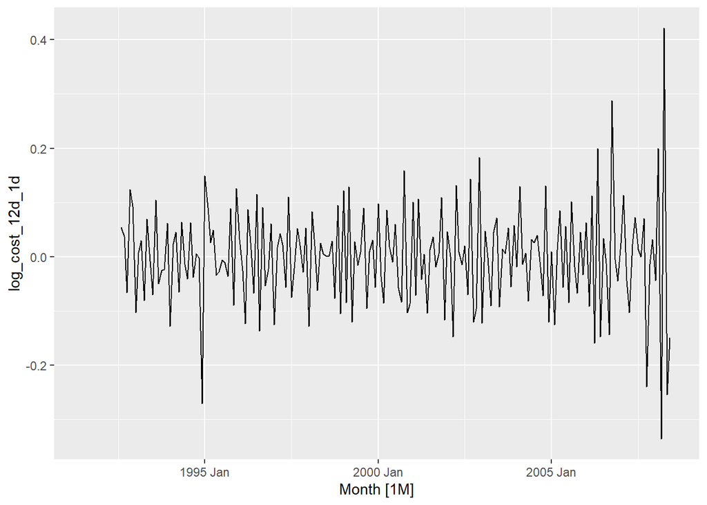

```r
a10 <- a10 %>% mutate(
  log_cost_12d_1d = log_cost_12d %>% difference(1)
)

autoplot(a10, log_cost_12d_1d)
```

```r
sum(!(a10$log_cost_12d_1d == a10$log_cost_1d_12d), na.rm = TRUE)
```

```
[1] 0
```

```r
# Alternative way of checking
identical(a10$log_cost_12d_1d, a10$log_cost_1d_12d)
```

```
[1] TRUE
```

## Example 2 - Transformation + differencing

```r
h02 <- PBS %>%
  filter(ATC2 == "H02") %>%
  summarise(Cost = sum(Cost)/1e6)
```

First the log transformation helps remove the increasing variance, which is itself a contributor to non-stationarity. Remember that **the transformation shall be applied prior to differencing**.

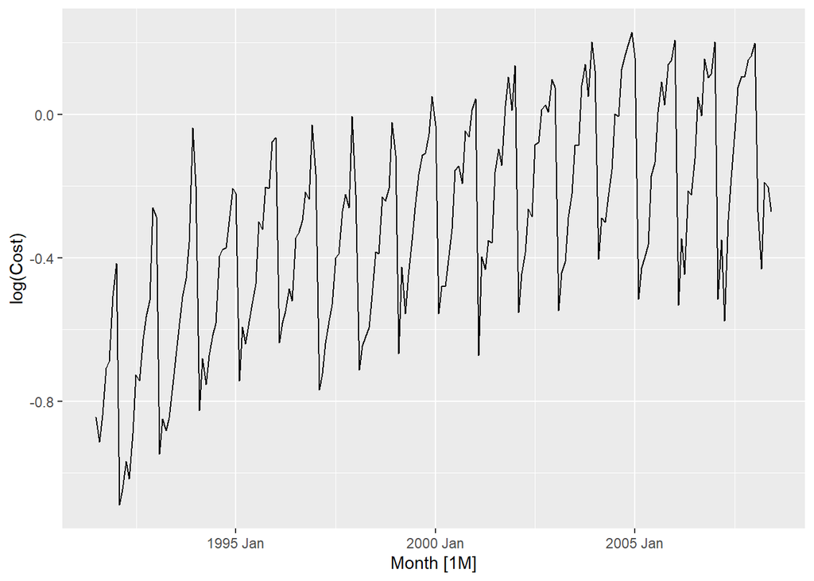

```r
h02 %>% autoplot(log(Cost))
```

Taking seasonal differences:

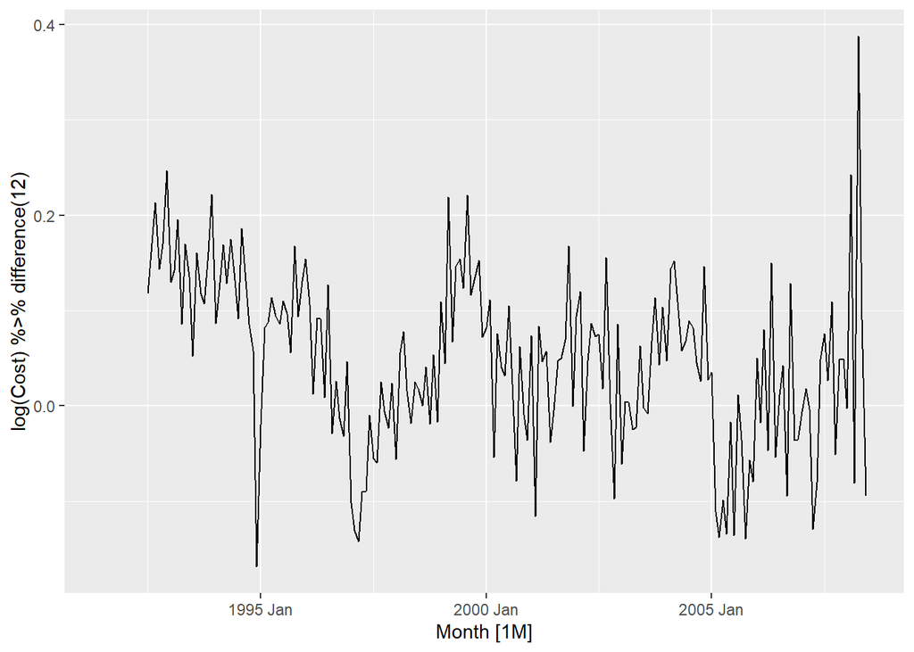

```r
h02 %>% autoplot(
  log(Cost) %>% difference(12)
)
```

In this case it looks as though the series could benefit from additional first order differencing:

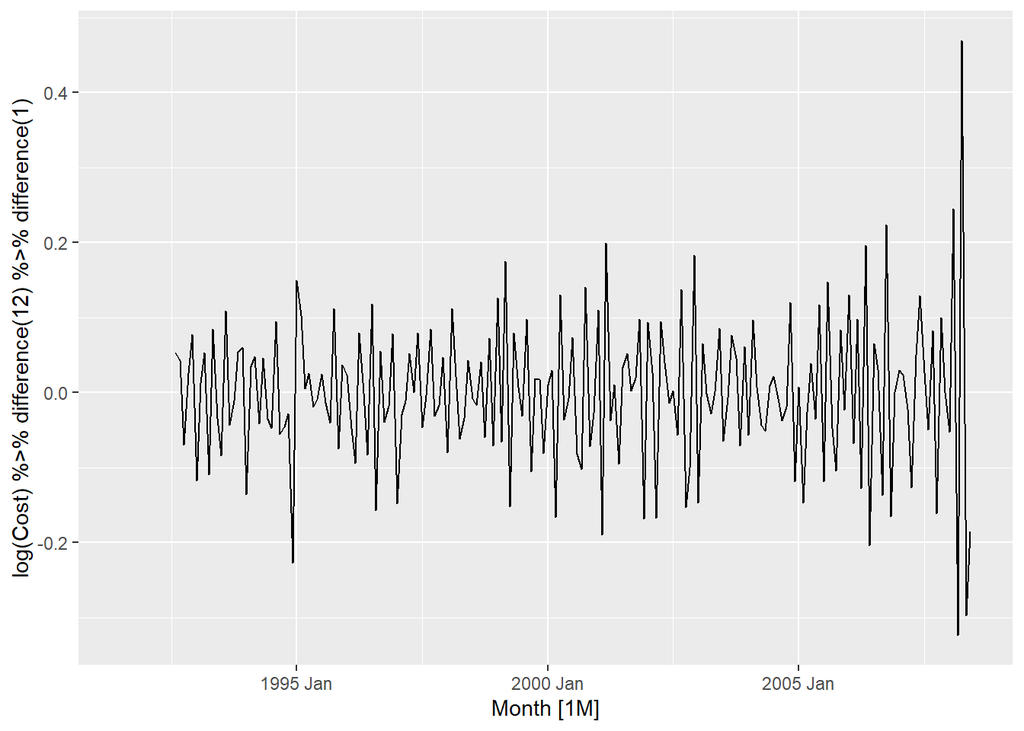

```r
h02 %>% autoplot(
  log(Cost) %>% difference(12) %>% difference(1)
)
```

Since we have applied subsequently seasonal and first order differencing, the resulting twice-differenced series is:

$$\begin{align*}
y^*_t = y'_t - y'_{t-1} = (y_t - y_{t-12}) - (y_{t-1}-y_{t-13}) = y_t-y_{t-1}-y_{t-12}+y_{t-13}
\end{align*}$$

## Note regarding the order of seasonal differencing vs 1st order differencing:

- If seasonal differencing is going to be used to remove the seasonality, then it is often best to apply it prior to first order differences. Seasonal differencing already contributes to removing non-stationary effects different from seasonality and thus it might be sufficient to render the time series stationary. If it is not, then subsequent differencing can help.
- If both steps are applied, it makes no difference which is applied first, the end result is the same.

# Interpretability of differencing

It is important that differencing, if used, remains interpretable.

- **First differences**: change from one observation to the next.
- **Seasonal differences**: change between one year and the next.
- **Other lags**: unlikely to make much interpretable sense.

# Unit root tests

*Unit root tests* are statistical hypothesis tests for stationarity.

- **Augmented Dickey-Fuller test:** null hypothesis is that the data are
  - **non-stationarity** and
  - **non-seasonal**
- **Kwiatkowski-Phillips-Schmidt-Shin** (KPSS) test: null hypothesis is that the data are
  - **stationary** and
  - **non-seasonal**.
- Other tests available for seasonal data

Depending on the test used, we might obtain different answers.

## KPSS test (Kwiatkowski-Phillips-Schmidt-Shin)

- **Null hypothesis** data are stationary.
- **Small p-values** suggest that differencing is required.

Can be computed using `unitroot_kpss()` function:

```r
google_2015 <- gafa_stock %>%
  filter(Symbol == "GOOG", year(Date) == 2015)

google_2015 %>%
  features(Close, unitroot_kpss)
```

```
# A tibble: 1 × 3
  Symbol kpss_stat kpss_pvalue
  <chr>      <dbl>       <dbl>
1 GOOG        3.56        0.01
```

When interpreting the output of the feature above in the `fable` library consider:

- The p-value is reported as 0.01 if it is less than 0.01
- The p-value is reported as 0.1 if it is greater than 0.1

Given the p-value, we can reject the null hypothesis and affirm that the data is not stationary.

Let us difference and re-compute the test:

```r
google_2015 %>%
  mutate(diff_close = difference(Close)) %>%
  features(diff_close, unitroot_kpss)
```

```
# A tibble: 1 × 3
  Symbol kpss_stat kpss_pvalue
  <chr>      <dbl>       <dbl>
1 GOOG      0.0989         0.1
```

This time the statistic is small and the actual p-value would be greater than 0.1. We therefore would fail to reject the null and conclude that this time-series is stationary.

### KPSS to determine the appropriate number of first differences:

The feautre `unitrott_ndiffs()` can be used for this:

#### Example 4 - unitroot_ndiffs

```r
google_2015 %>%
  features(Close, unitroot_ndiffs)
```

```
# A tibble: 1 × 2
  Symbol ndiffs
  <chr>   <int>
1 GOOG        1
```

The above tells us that it is necessary to perform one first order difference to renderr the google stock data stationary, which we already checked.

### KPSS to determine if seasonal differencing is required:

Using `unitroot_nsdiffs` this can be done. It uses a measure of the **seasonal strength** to determine the appropriate number of seasonal differences required.

#### Seasonal strength

Recall that a time series decomposition can be written as: $y_t = T_t + S_{t} + R_t$

- $T_t$ is the smoothed trend component
- $S_t$ is the seasonal component
- $R_t$ is the remainder component

$$\begin{align*}
F_S = \max\left(0, 1 - \frac{\text{Var}(R_t)}{\text{Var}(S_{t}+R_t)}\right)
\end{align*}$$

The function `unitroot_nsdiffs()` suggest no seasonal differences if $F_s < 0.64$. Otherwise one seasonal difference is suggested.

#### Example 4 - unitroot_nsdiffs

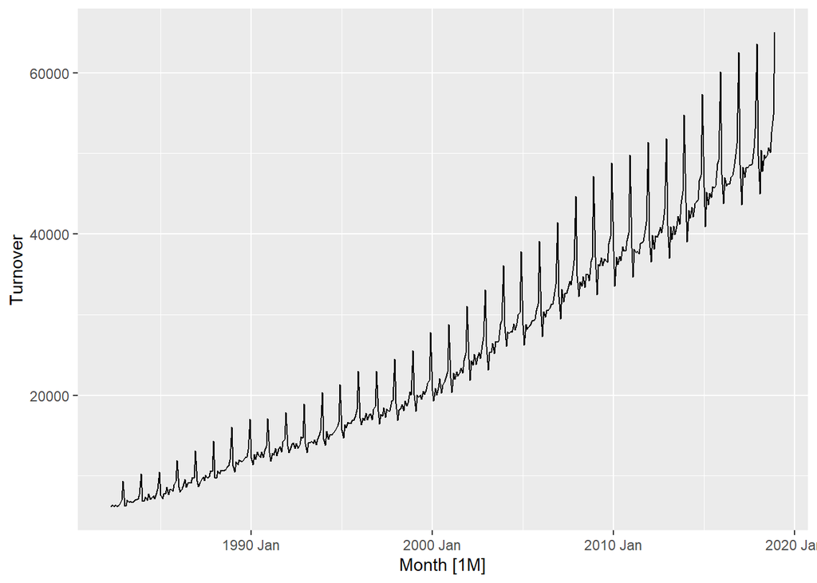

```r
aus_total_retail <- aus_retail %>%
  summarise(Turnover = sum(Turnover))

aus_total_retail %>% autoplot(Turnover)
```

```r
aus_total_retail %>%
  mutate(log_turnover = log(Turnover)) %>%
  features(log_turnover, unitroot_nsdiffs)
```

```
# A tibble: 1 × 1
  nsdiffs
    <int>
1       1
```

This suggest we should apply one seasonal difference

We do this and then apply `unitroot_ndiffs` to see if further differencing is suggested.

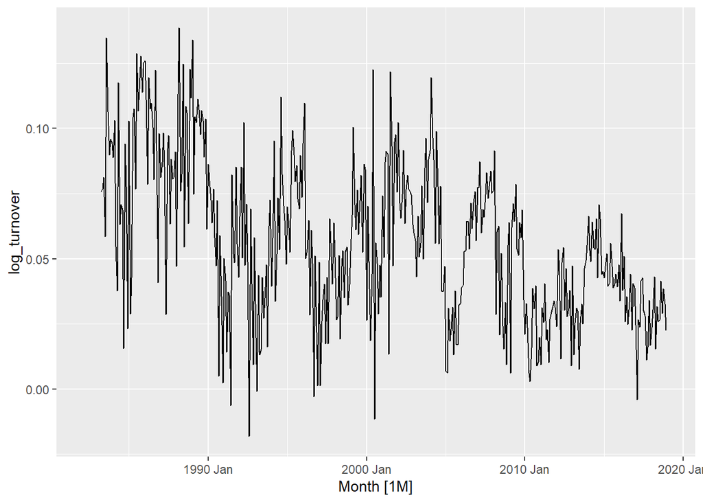

```r
aus_total_retail_sdfiff <- aus_total_retail %>%
  mutate(log_turnover = difference(log(Turnover), 12))

aus_total_retail_sdfiff %>% autoplot(log_turnover)
```

We can see there remains a certain amount of trend. Lets see if a lag-1 difference is suggested

```r
aus_total_retail_sdfiff %>%
  features(log_turnover, unitroot_ndiffs)
```

```
# A tibble: 1 × 1
  ndiffs
   <int>
1      1
```

As we can see, a 1-lag difference is still suggested. Lets perform it and inspect the result:

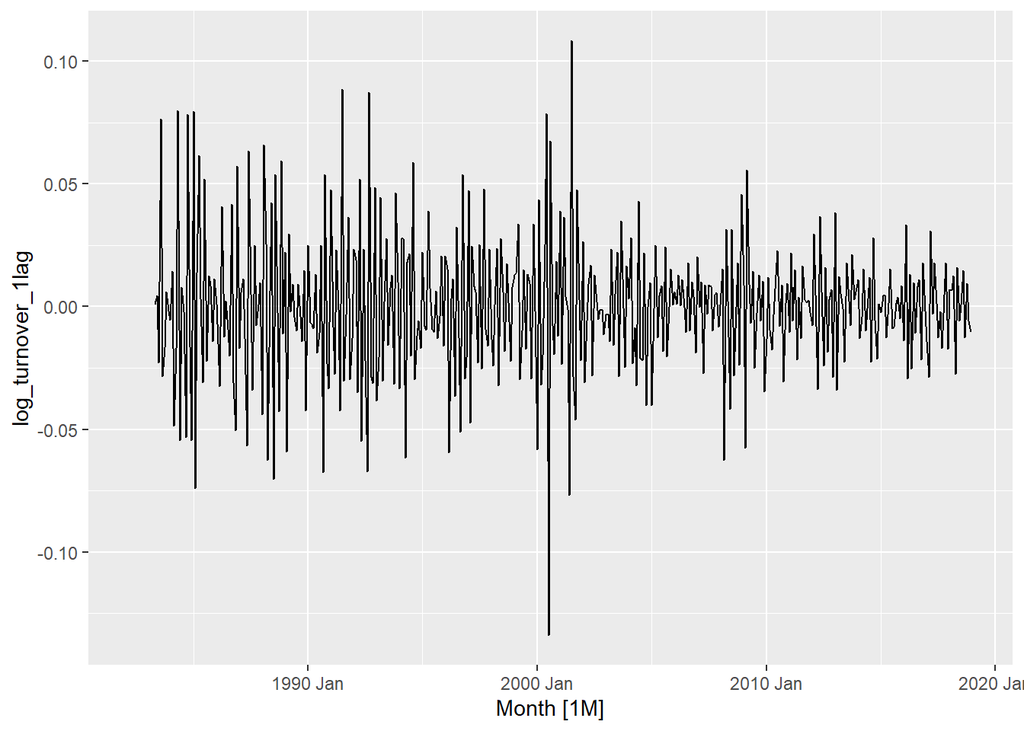

```r
aus_total_retail_sdfiff %>%
  mutate(log_turnover_1lag = difference(log_turnover, 1)) %>% autoplot(log_turnover_1lag)
```

Now the series has a much more stationary aspect.

```r
aus_total_retail_sdfiff %>%
  mutate(log_turnover_1lag = difference(log_turnover, 1)) %>%
   features(log_turnover_1lag, unitroot_kpss)
```

```
# A tibble: 1 × 2
  kpss_stat kpss_pvalue
      <dbl>       <dbl>
1    0.0135         0.1
```

## Other tests for stationarity

Other tests of stationairity you may research include:

- Augmented Dickey-Füller test.

# Backshift notation

The backwards shift operator $B$ is useful when working with lags. Some references use $L$ for “lags” instead of B:

$$\begin{align*}
B y_{t} = y_{t - 1}
\end{align*}$$

Two consecutive applications shift the data back two periods. Notice the definition of the **power** of the backshift operator. This definition will be useful when handling more complex differences in ARIMA:

$$\begin{align*}
B(By_{t}) = B^{2}y_{t} = y_{t-2}
\end{align*}$$

It can be used to signal seasonal differences as well, using $m$ to indicate thenumber of times the backshift notation is applied. **Example**: monthly data and *same month last year*:

$$\begin{align*}
B^{12}y_{t} = y_{t-12}
\end{align*}$$

To describe the process of differencing, the backshift notation is quite convenient. Let us see the expression for the first, second order differences and, more generallt $d$th-order difference:

$$\begin{align*}
y'_{t} = y_{t} - y_{t-1} = y_t - By_{t} = (1 - B)y_{t} \\
y''_{t} = y_{t} - 2y_{t - 1} + y_{t - 2} = (1-2B+B^2)y_t = (1 - B)^{2} y_{t} \\
\text{d-th order difference: }(1 - B)^{d} y_{t}
\end{align*}$$

**The backshift operator is convenient because the terms can be multiplied together to compute their combined effect**.

**Example**: Seasonal difference of order $m$ followed by a first difference (same result we obtained earler):

$$\begin{align*}
(1-B)(1-B^m)y_t &= (1 - B - B^m + B^{m+1})y_t \\
&= y_t-y_{t-1}-y_{t-m}+y_{t-m-1},
\end{align*}$$

Substituting $m=12$ you can see that you reach exactly what we obtained before in this sesion when we subsequently applied seasonal differences and first order differences to the h02 dataset

$$\begin{align*}
y^*_t = y'_t - y'_{t-1} = (y_t - y_{t-12}) - (y_{t-1}-y_{t-13}) = y_t-y_{t-1}-y_{t-12}+y_{t-13}
\end{align*}$$

# Exercises

## Ex 1. For the following series, find an appropriate Box-Cox transformation and order of differencing in order to obtain stationary data.

### 1.a Turkish GDP from `global_economy`

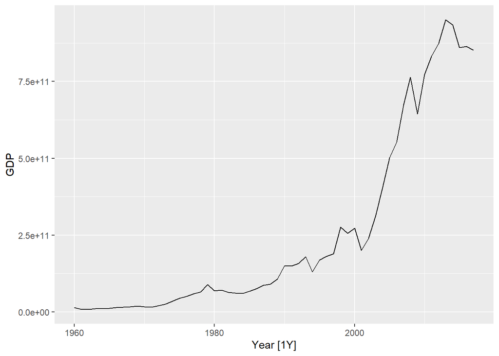

```r
turkey <- global_economy %>% filter(Country == "Turkey")
turkey %>% autoplot(GDP)
```

```r
The trend is non-linear. Have several options:

1. Perform higher order differences. Since the trend is non-linear one difference
  would probably not remove the trend and we would have to take further differences

2. Lineariza with a box-cox transformation and then take differences. Since we
have linearized a first order difference would probably suffice to remove the
trend.
```

```r
lambda_turkey <- turkey %>% features(GDP, guerrero) %>% pull(lambda_guerrero)
lambda_turkey
```

```
[1] 0.1572187
```

```r
turkey <- turkey %>%
            mutate(
              log_GDP = log(GDP),
              bc_GDP = box_cox(GDP, lambda_turkey),
              diff_logGDP = difference(log_GDP, 1),
              diff_bc_GDP = difference(bc_GDP, 1)
              )
```

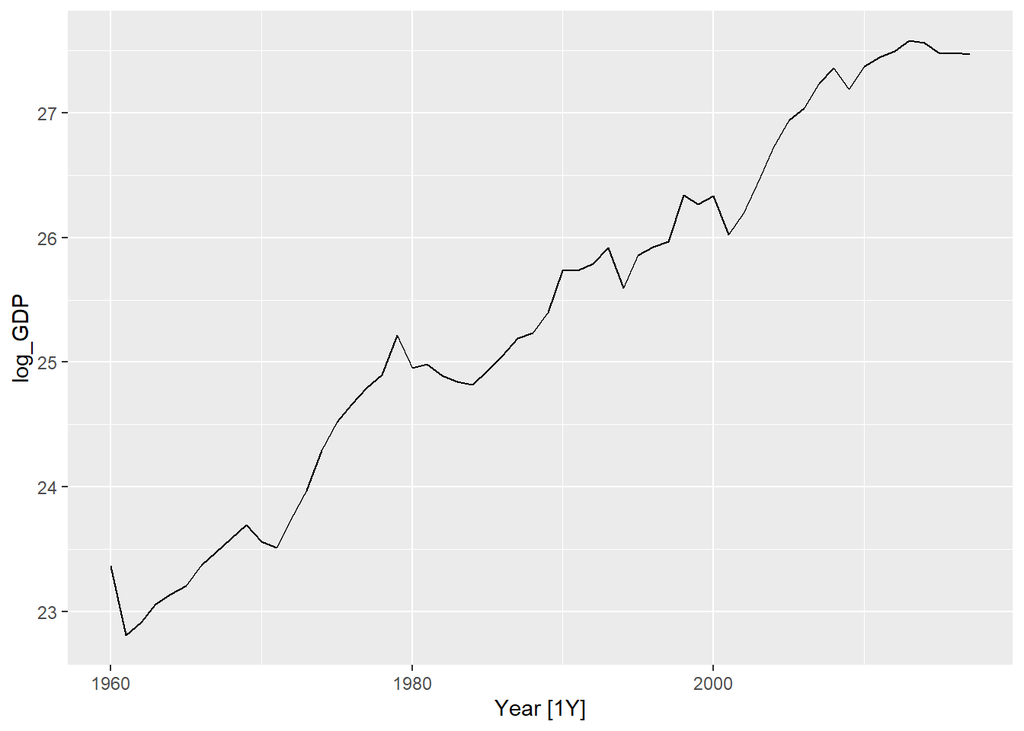

```r
turkey %>% autoplot(log_GDP)
```

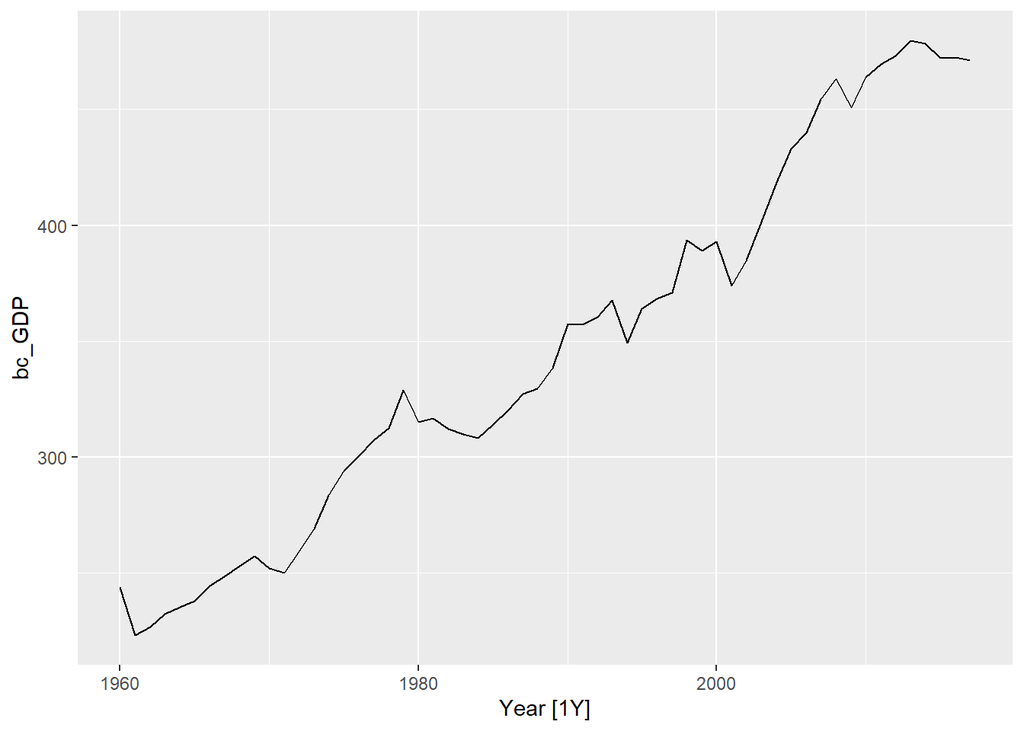

```r
turkey %>% autoplot(bc_GDP)
```

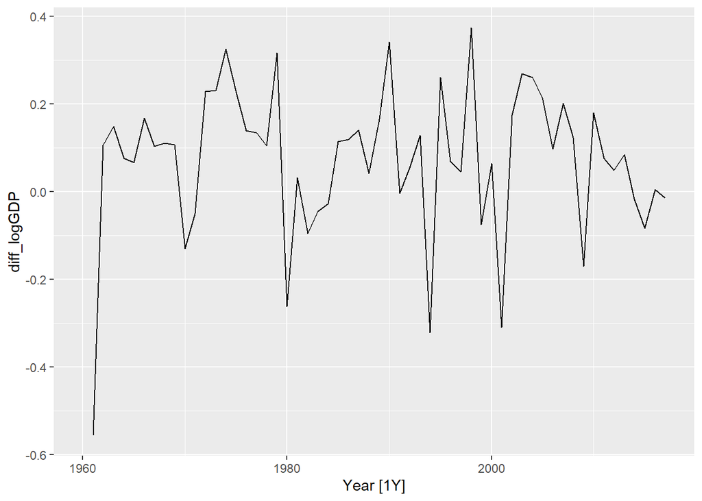

```r
turkey %>% autoplot(diff_logGDP)
```

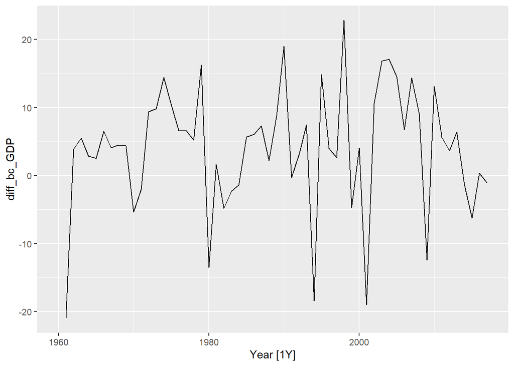

```r
turkey %>% autoplot(diff_bc_GDP)
```

```r
turkey %>%
  features(diff_logGDP, unitroot_kpss)
```

```
# A tibble: 1 × 3
  Country kpss_stat kpss_pvalue
  <fct>       <dbl>       <dbl>
1 Turkey     0.0603         0.1
```

```r
turkey %>%
  features(diff_bc_GDP, unitroot_kpss)
```

```
# A tibble: 1 × 3
  Country kpss_stat kpss_pvalue
  <fct>       <dbl>       <dbl>
1 Turkey     0.0889         0.1
```

```r
Both the lambda and the bc transformation have a p-value that fails to
reject the null. We fail to reject H0, assessing the series as stationary
```